# Regression Analysis: Companion R Notebook

Version 0.9.3

Alexis Diamond, PhD (assisted by Claude and ChatGPT)

September 30, 2026

This notebook accompanies the regression-analysis chapters. Run the chunks in order. All statistical and plotting code uses base R grammar; no tidyverse syntax is required.

# Chapter 1: Introducing Regression as a Prediction Machine

## Conditional means and a fitted regression

The empirical conditional means show what it means to ask for the expected value of `Y` at each observed value of `X`. The fitted line is one rule for generating predictions.

```r
x <- rep(c(1, 2, 3, 4), each = 5)
y <- c(3, 4, 4, 5, 4,
       5, 5, 6, 7, 7,
       7, 8, 8, 9, 8,
       9, 10, 11, 10, 10)

dat <- data.frame(x, y)

tapply(dat$y, dat$x, mean)
```

```
##  1  2  3  4
##  4  6  8 10
```

```r
fit <- lm(y ~ x, data = dat)
summary(fit)
```

```
##
## Call:
## lm(formula = y ~ x, data = dat)
##
## Residuals:
##    Min     1Q Median     3Q    Max
##  -1.00  -0.25   0.00   0.25   1.00
##
## Coefficients:
##             Estimate Std. Error t value Pr(>|t|)
## (Intercept)   2.0000     0.4082   4.899 0.000116 ***
## x             2.0000     0.1491  13.416 8.21e-11 ***
## ---
## Signif. codes:  0 '***' 0.001 '**' 0.01 '*' 0.05 '.' 0.1 ' ' 1
##
## Residual standard error: 0.7454 on 18 degrees of freedom
## Multiple R-squared:  0.9091, Adjusted R-squared:  0.904
## F-statistic:   180 on 1 and 18 DF,  p-value: 8.209e-11
```

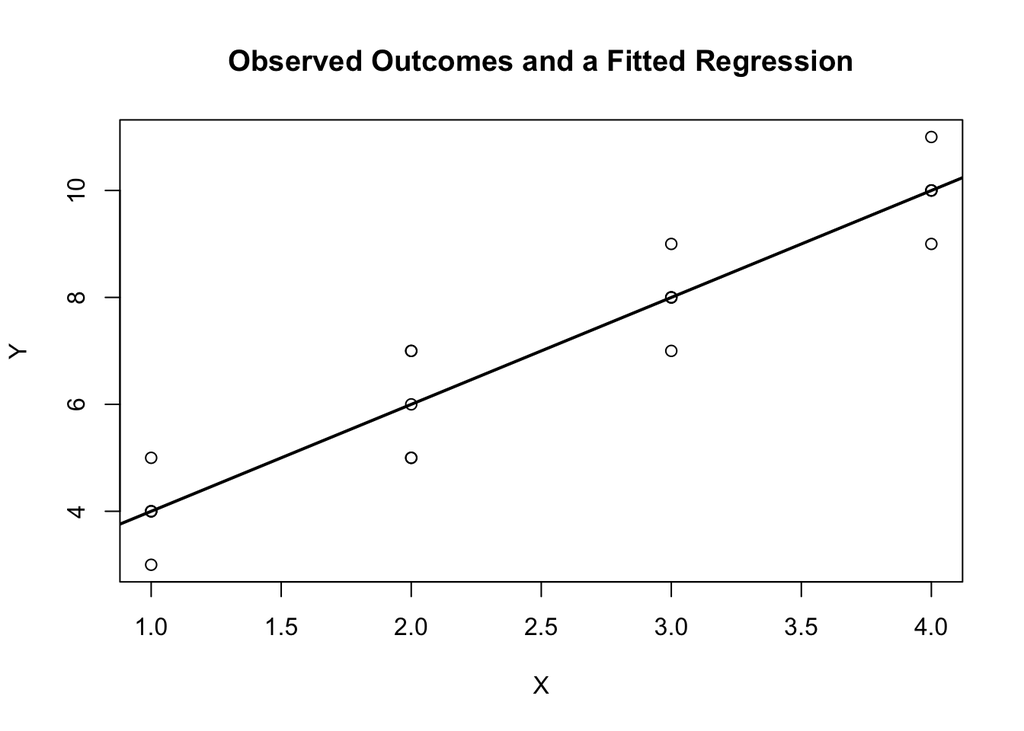

```r
plot(
  dat$x,
  dat$y,
  xlab = "X",
  ylab = "Y",
  main = "Observed Outcomes and a Fitted Regression"
)
abline(fit, lwd = 2)
```

## An expected value need not be observable

The word *expect* is a technical term here. An expected value is the center of a distribution, and the center is often a value that no individual could ever have.

```r
# A binary outcome: 1 = employed, 0 = not employed.
employed <- c(1, 1, 1, 1, 0, 1, 1, 1, 0, 1)

mean(employed)   # 0.8
```

```
## [1] 0.8
```

```r
# Every person is a 0 or a 1, so no one has the value 0.8:
sort(unique(employed))
```

```
## [1] 0 1
```

```r
# For a binary Y the conditional mean IS the probability that Y = 1.
# A count outcome makes the same point:
visits <- c(7, 9, 10, 11, 14)
mean(visits)     # 10.2 -- not a possible number of visits
```

```
## [1] 10.2
```

The conditional mean is still the right prediction in both cases. It is the best single guess about the group, not a forecast of any one person’s outcome.

## Linear regression and LOESS

Both methods are prediction machines for a conditional mean, but they impose very different amounts of structure.

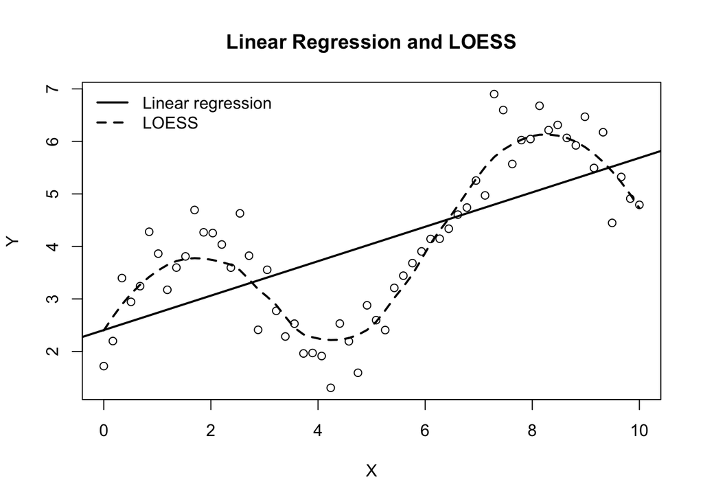

```r
set.seed(123)

x <- seq(0, 10, length.out = 60)
y <- 2 + 0.35 * x + 1.5 * sin(x) + rnorm(60, sd = 0.5)

dat_curve <- data.frame(x, y)

fit_linear <- lm(y ~ x, data = dat_curve)
fit_loess <- loess(y ~ x, data = dat_curve, span = 0.60)

plot(
  dat_curve$x,
  dat_curve$y,
  xlab = "X",
  ylab = "Y",
  main = "Linear Regression and LOESS"
)
abline(fit_linear, lwd = 2)

ord <- order(dat_curve$x)
lines(
  dat_curve$x[ord],
  predict(fit_loess)[ord],
  lwd = 2,
  lty = 2
)

legend(
  "topleft",
  legend = c("Linear regression", "LOESS"),
  lty = c(1, 2),
  lwd = 2,
  bty = "n"
)
```

## Different regression families for different outcomes

The following examples show continuous, binary, count, and flexible conditional-mean models.

```r
set.seed(42)

# Continuous outcome
x_cont <- runif(200, 0, 10)
y_cont <- 4 + 2 * x_cont + rnorm(200, sd = 3)
dat_cont <- data.frame(x = x_cont, y_cont = y_cont)
fit_ols <- lm(y_cont ~ x, data = dat_cont)

# Binary outcome
x_binary <- runif(200, 0, 10)
p_binary <- 1 / (1 + exp(-(-3 + 0.6 * x_binary)))
y_binary <- rbinom(200, size = 1, prob = p_binary)
dat_binary <- data.frame(x = x_binary, y_binary = y_binary)
fit_logit <- glm(
  y_binary ~ x,
  family = binomial(link = "logit"),
  data = dat_binary
)

# Count outcome
x_count <- runif(200, 0, 5)
lambda <- exp(0.4 + 0.25 * x_count)
count <- rpois(200, lambda = lambda)
dat_count <- data.frame(x = x_count, count = count)
fit_pois <- glm(
  count ~ x,
  family = poisson(link = "log"),
  data = dat_count
)

# Flexible conditional-mean smoother
fit_loess <- loess(y ~ x, data = dat_curve)

summary(fit_ols)
```

```
##
## Call:
## lm(formula = y_cont ~ x, data = dat_cont)
##
## Residuals:
##     Min      1Q  Median      3Q     Max
## -7.9344 -1.8695  0.0093  1.8318  8.2710
##
## Coefficients:
##             Estimate Std. Error t value Pr(>|t|)
## (Intercept)  3.82928    0.41936   9.131   <2e-16 ***
## x            2.00459    0.07013  28.583   <2e-16 ***
## ---
## Signif. codes:  0 '***' 0.001 '**' 0.01 '*' 0.05 '.' 0.1 ' ' 1
##
## Residual standard error: 2.889 on 198 degrees of freedom
## Multiple R-squared:  0.8049, Adjusted R-squared:  0.8039
## F-statistic:   817 on 1 and 198 DF,  p-value: < 2.2e-16
```

```r
summary(fit_logit)
```

```
##
## Call:
## glm(formula = y_binary ~ x, family = binomial(link = "logit"),
##     data = dat_binary)
##
## Coefficients:
##             Estimate Std. Error z value Pr(>|z|)
## (Intercept) -3.39129    0.48103  -7.050 1.79e-12 ***
## x            0.62633    0.08464   7.399 1.37e-13 ***
## ---
## Signif. codes:  0 '***' 0.001 '**' 0.01 '*' 0.05 '.' 0.1 ' ' 1
##
## (Dispersion parameter for binomial family taken to be 1)
##
##     Null deviance: 276.28  on 199  degrees of freedom
## Residual deviance: 186.63  on 198  degrees of freedom
## AIC: 190.63
##
## Number of Fisher Scoring iterations: 4
```

```r
summary(fit_pois)
```

```
##
## Call:
## glm(formula = count ~ x, family = poisson(link = "log"), data = dat_count)
##
## Coefficients:
##             Estimate Std. Error z value Pr(>|z|)
## (Intercept)  0.41540    0.09398   4.420 9.87e-06 ***
## x            0.23250    0.02872   8.095 5.72e-16 ***
## ---
## Signif. codes:  0 '***' 0.001 '**' 0.01 '*' 0.05 '.' 0.1 ' ' 1
##
## (Dispersion parameter for poisson family taken to be 1)
##
##     Null deviance: 264.57  on 199  degrees of freedom
## Residual deviance: 196.52  on 198  degrees of freedom
## AIC: 730.87
##
## Number of Fisher Scoring iterations: 5
```

## Zeros in a count regression

An observed count can be zero. A fitted Poisson mean never is.

```r
# Zeros are ordinary observations in count data:
sum(dat_count$count == 0)
```

```
## [1] 13
```

```r
min(dat_count$count)
```

```
## [1] 0
```

```r
# But no fitted value is ever zero, because lambda = exp(X %*% beta) > 0 always:
lambda_hat <- fitted(fit_pois)
min(lambda_hat)
```

```
## [1] 1.525057
```

```r
# The model never predicts zero; it assigns zero a probability.
# At the smallest fitted mean, P(Y = 0) = exp(-lambda):
exp(-min(lambda_hat))
```

```
## [1] 0.2176087
```

# Chapter 2: Technical Foundations of OLS

## Binary predictor: coefficient equals the difference in means

```r
D <- c(rep(0, 5), rep(1, 5))
Y <- c(4, 5, 6, 7, 8,
       7, 8, 9, 10, 11)

dat_binary_ols <- data.frame(D, Y)

fit_binary <- lm(Y ~ D, data = dat_binary_ols)
summary(fit_binary)
```

```
##
## Call:
## lm(formula = Y ~ D, data = dat_binary_ols)
##
## Residuals:
##    Min     1Q Median     3Q    Max
##     -2     -1      0      1      2
##
## Coefficients:
##             Estimate Std. Error t value Pr(>|t|)
## (Intercept)   6.0000     0.7071   8.485 2.85e-05 ***
## D             3.0000     1.0000   3.000   0.0171 *
## ---
## Signif. codes:  0 '***' 0.001 '**' 0.01 '*' 0.05 '.' 0.1 ' ' 1
##
## Residual standard error: 1.581 on 8 degrees of freedom
## Multiple R-squared:  0.5294, Adjusted R-squared:  0.4706
## F-statistic:     9 on 1 and 8 DF,  p-value: 0.01707
```

```r
coef(fit_binary)
```

```
## (Intercept)           D
##           6           3
```

```r
mean(dat_binary_ols$Y[dat_binary_ols$D == 0])
```

```
## [1] 6
```

```r
mean(dat_binary_ols$Y[dat_binary_ols$D == 1])
```

```
## [1] 9
```

```r
mean(dat_binary_ols$Y[dat_binary_ols$D == 1]) -
  mean(dat_binary_ols$Y[dat_binary_ols$D == 0])
```

```
## [1] 3
```

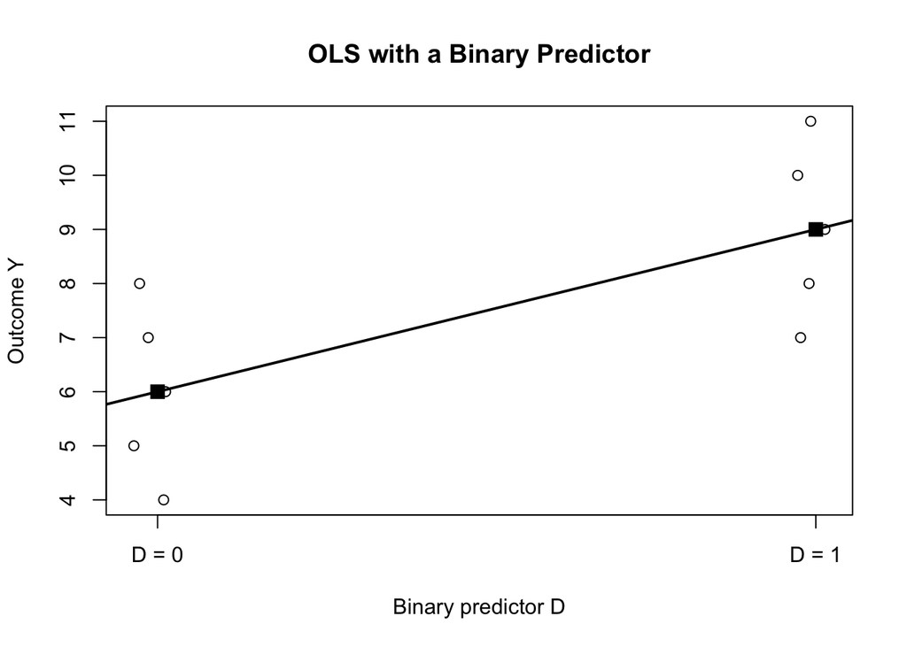

```r
plot(
  jitter(dat_binary_ols$D, amount = 0.04),
  dat_binary_ols$Y,
  xaxt = "n",
  xlab = "Binary predictor D",
  ylab = "Outcome Y",
  main = "OLS with a Binary Predictor"
)
axis(1, at = c(0, 1), labels = c("D = 0", "D = 1"))

abline(fit_binary, lwd = 2)
points(
  c(0, 1),
  c(
    mean(dat_binary_ols$Y[dat_binary_ols$D == 0]),
    mean(dat_binary_ols$Y[dat_binary_ols$D == 1])
  ),
  pch = 15,
  cex = 1.5
)
```

## Regression coefficients are literal prediction instructions

```r
fit_cars <- lm(dist ~ speed, data = cars)
summary(fit_cars)
```

```
##
## Call:
## lm(formula = dist ~ speed, data = cars)
##
## Residuals:
##     Min      1Q  Median      3Q     Max
## -29.069  -9.525  -2.272   9.215  43.201
##
## Coefficients:
##             Estimate Std. Error t value Pr(>|t|)
## (Intercept) -17.5791     6.7584  -2.601   0.0123 *
## speed         3.9324     0.4155   9.464 1.49e-12 ***
## ---
## Signif. codes:  0 '***' 0.001 '**' 0.01 '*' 0.05 '.' 0.1 ' ' 1
##
## Residual standard error: 15.38 on 48 degrees of freedom
## Multiple R-squared:  0.6511, Adjusted R-squared:  0.6438
## F-statistic: 89.57 on 1 and 48 DF,  p-value: 1.49e-12
```

```r
coef(fit_cars)
```

```
## (Intercept)       speed
##  -17.579095    3.932409
```

```r
# Predictions for training observations
train_predictions <- predict(fit_cars)
head(data.frame(
  speed = cars$speed,
  observed_dist = cars$dist,
  predicted_dist = train_predictions
))
```

```
##   speed observed_dist predicted_dist
## 1     4             2      -1.849460
## 2     4            10      -1.849460
## 3     7             4       9.947766
## 4     7            22       9.947766
## 5     8            16      13.880175
## 6     9            10      17.812584
```

```r
# Predictions for new cases
new_cases <- data.frame(speed = c(10, 15, 20))
new_cases$predicted_dist <- predict(
  fit_cars,
  newdata = new_cases
)
new_cases
```

```
##   speed predicted_dist
## 1    10       21.74499
## 2    15       41.40704
## 3    20       61.06908
```

```r
# Reproduce predict() literally from the coefficients
b <- coef(fit_cars)
manual_predictions <- b[1] + b[2] * new_cases$speed
cbind(new_cases, manual_predictions = manual_predictions)
```

```
##   speed predicted_dist manual_predictions
## 1    10       21.74499           21.74499
## 2    15       41.40704           41.40704
## 3    20       61.06908           61.06908
```

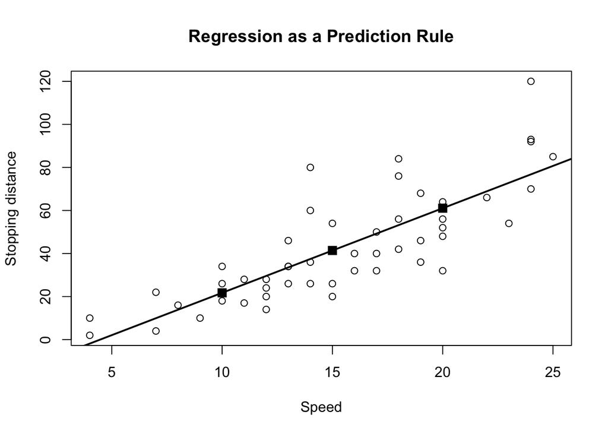

```r
plot(
  cars$speed,
  cars$dist,
  xlab = "Speed",
  ylab = "Stopping distance",
  main = "Regression as a Prediction Rule"
)
abline(fit_cars, lwd = 2)
points(
  new_cases$speed,
  new_cases$predicted_dist,
  pch = 15,
  cex = 1.4
)
```

## Coefficient uncertainty: standard errors, p-values, and confidence intervals

```r
confint(fit_cars, level = 0.95)
```

```
##                  2.5 %    97.5 %
## (Intercept) -31.167850 -3.990340
## speed         3.096964  4.767853
```

```r
coef_table <- summary(fit_cars)$coefficients
coef_table
```

```
##               Estimate Std. Error   t value     Pr(>|t|)
## (Intercept) -17.579095  6.7584402 -2.601058 1.231882e-02
## speed         3.932409  0.4155128  9.463990 1.489836e-12
```

```r
b_speed <- coef_table["speed", "Estimate"]
se_speed <- coef_table["speed", "Std. Error"]

# Approximate 95% confidence interval
b_speed + c(-1, 1) * 2 * se_speed
```

```
## [1] 3.101383 4.763434
```

## Mean squared error and R-squared

```r
fit_cars <- lm(dist ~ speed, data = cars)

summary(fit_cars)$r.squared
```

```
## [1] 0.6510794
```

```r
mse_mean_only <- mean(
  (cars$dist - mean(cars$dist))^2
)

mse_model <- mean(
  (cars$dist - predict(fit_cars))^2
)

mse_mean_only
```

```
## [1] 650.7796
```

```r
mse_model
```

```
## [1] 227.0704
```

```r
1 - mse_model / mse_mean_only
```

```
## [1] 0.6510794
```

## Reducible and irreducible error

Here we know the data-generating process, so we can measure the floor that no model can get under. Reducible error shrinks as the training sample grows; irreducible error does not move at all.

```r
set.seed(7)

# The true DGP: Y = f(X) + epsilon, with f known to us only in a simulation.
f <- function(x) 2 + 0.8 * x
sigma <- 2

simulate_data <- function(n) {
  x <- runif(n, 0, 10)
  data.frame(x = x, y = f(x) + rnorm(n, sd = sigma))
}

# A large test set, used to measure out-of-sample prediction error.
test <- simulate_data(5000)

# The oracle: predict using the TRUE f. No model can beat this.
oracle_mse <- mean((test$y - f(test$x))^2)

# Fit on training samples of different sizes and score on the same test set.
test_mse_at <- function(n) {
  train <- simulate_data(n)
  fit <- lm(y ~ x, data = train)
  mean((test$y - predict(fit, newdata = test))^2)
}

round(
  c(
    irreducible = sigma^2,      # Var(epsilon): the floor
    oracle      = oracle_mse,   # the true f, estimated on nothing
    n_25        = test_mse_at(25),
    n_250       = test_mse_at(250),
    n_10000     = test_mse_at(10000)
  ),
  3
)
```

```
## irreducible      oracle        n_25       n_250     n_10000
##       4.000       4.060       5.267       4.088       4.061
```

The fitted models approach the oracle as `n` grows – that closing gap is the reducible error. What none of them get below is `sigma^2`.

# Chapter 3: Prediction Uncertainty and Multiple Regression

## Three different interval targets

```r
fit <- lm(dist ~ speed, data = cars)

# 1. Confidence intervals for regression coefficients
confint(fit)
```

```
##                  2.5 %    97.5 %
## (Intercept) -31.167850 -3.990340
## speed         3.096964  4.767853
```

```r
# 2. Confidence interval for the conditional mean at speed = 15
predict(
  fit,
  newdata = data.frame(speed = 15),
  interval = "confidence"
)
```

```
##        fit      lwr      upr
## 1 41.40704 37.02115 45.79292
```

```r
# 3. Prediction interval for one new observation at speed = 15
predict(
  fit,
  newdata = data.frame(speed = 15),
  interval = "prediction"
)
```

```
##        fit      lwr      upr
## 1 41.40704 10.17482 72.63925
```

## Why a coefficient’s interval cannot be rescaled into a prediction’s

The estimated coefficients are not independent, so uncertainty about a fitted value depends on the whole variance-covariance matrix, not on one standard error.

```r
fit <- lm(dist ~ speed, data = cars)

# The variance-covariance matrix: variances on the diagonal,
# covariances off it.
vcov(fit)
```

```
##             (Intercept)      speed
## (Intercept)   45.676514 -2.6588234
## speed         -2.658823  0.1726509
```

```r
# As a correlation, the two estimates are nearly redundant:
cov2cor(vcov(fit))
```

```
##             (Intercept)      speed
## (Intercept)   1.0000000 -0.9468008
## speed        -0.9468008  1.0000000
```

```r
# The off-diagonal entry is exactly -xbar * Var(beta1hat):
c(
  off_diagonal = vcov(fit)["(Intercept)", "speed"],
  formula      = -mean(cars$speed) * vcov(fit)["speed", "speed"]
)
```

```
## off_diagonal      formula
##    -2.658823    -2.658823
```

```r
# CORRECT interval for the conditional mean at speed = 15:
predict(fit, newdata = data.frame(speed = 15), interval = "confidence")
```

```
##        fit      lwr      upr
## 1 41.40704 37.02115 45.79292
```

```r
# NAIVE first difference: hold the intercept fixed and swing the slope
# across the ends of its own confidence interval.
coef(fit)[1] + confint(fit)["speed", ] * 15
```

```
##    2.5 %   97.5 %
## 28.87537 53.93870
```

The naive interval is about three times too wide. The decomposition shows why: the covariance term is negative and larger in magnitude than either variance, so most of the coefficient uncertainty cancels when the two are combined.

```r
V <- vcov(fit)
x <- 15

terms <- c(
  var_b0     = V[1, 1],
  x2_var_b1  = x^2 * V[2, 2],
  cross_term = 2 * x * V[1, 2]
)
terms
```

```
##     var_b0  x2_var_b1 cross_term
##   45.67651   38.84645  -79.76470
```

```r
sum(terms)
```

```
## [1] 4.758258
```

```r
# Standard errors: correct versus naive.
c(
  correct = sqrt(sum(terms)),
  naive   = x * sqrt(V[2, 2])
)
```

```
##  correct    naive
## 2.181343 6.232692
```

```r
# The general formula, c' V c, reproduces what predict() reports:
cvec <- c(1, x)
sqrt(t(cvec) %*% V %*% cvec)
```

```
##          [,1]
## [1,] 2.181343
```

With no intercept there is only one coefficient, so there is no covariance to ignore and the shortcut becomes exact.

```r
fit0 <- lm(dist ~ speed - 1, data = cars)

vcov(fit0)   # a 1x1 matrix
```

```
##            speed
## speed 0.01998509
```

```r
predict(fit0, newdata = data.frame(speed = 15), interval = "confidence")
```

```
##        fit      lwr      upr
## 1 43.63698 39.37562 47.89835
```

```r
confint(fit0)["speed", ] * 15   # identical, to every printed digit
```

```
##    2.5 %   97.5 %
## 39.37562 47.89835
```

The naive width is a straight line in `x`; the correct width is a hyperbola with its minimum at `xbar`. Different shapes, so they can cross but cannot coincide. Note the `x = 0` row: the shortcut claims perfect certainty about `E[Y | X = 0]`, which is just the intercept, whose standard error is printed in the regression output.

```r
tq <- qt(0.975, df.residual(fit))
s  <- summary(fit)$sigma

naive_width <- function(x) 2 * tq * x * sqrt(V[2, 2])
ci_width    <- function(x) 2 * tq * sqrt(V[1, 1] + x^2 * V[2, 2] + 2 * x * V[1, 2])
pi_width    <- function(x) 2 * tq * sqrt(s^2 + V[1, 1] + x^2 * V[2, 2] + 2 * x * V[1, 2])

# The one x where the shortcut happens to be right:
# solve Var(b0) + 2x Cov = 0  =>  x* = mean(x^2) / (2 * mean(x))
xstar <- mean(cars$speed^2) / (2 * mean(cars$speed))

xs <- c(0, 5, xstar, mean(cars$speed), 20, 25, 100)
round(
  data.frame(
    x             = xs,
    naive         = naive_width(xs),
    correct_ci    = ci_width(xs),
    prediction    = pi_width(xs),
    naive_over_ci = naive_width(xs) / ci_width(xs)
  ),
  3
)
```

```
##        x   naive correct_ci prediction naive_over_ci
## 1   0.00   0.000     27.178     67.554         0.000
## 2   5.00   8.354     19.454     64.833         0.429
## 3   8.59  14.352     14.352     63.489         1.000
## 4  15.40  25.732      8.746     62.461         2.942
## 5  20.00  33.418     11.644     62.932         2.870
## 6  25.00  41.772     18.270     64.488         2.286
## 7 100.00 167.089    141.628    154.542         1.180
```

```r
range(cars$speed)   # x* falls INSIDE the observed data
```

```
## [1]  4 25
```

The shortcut is too narrow for small `x`, exactly right at one point, and almost three times too wide near the middle of the data. It is not reliably conservative, and it never comes close to the prediction interval – it contains no information about the spread of `Y` around the line at all.

A first difference across two values of `x` is a different question. In the simple model the intercept cancels, so rescaling the slope’s interval is legitimate – but that survives only because the difference loads on a single coefficient. Add a quadratic term and it fails again.

```r
# Simple model: the difference depends on beta1 alone, so both agree.
c(
  full  = sqrt(t(c(0, 5)) %*% vcov(fit) %*% c(0, 5)),
  naive = 5 * sqrt(vcov(fit)["speed", "speed"])
)
```

```
##     full    naive
## 2.077564 2.077564
```

```r
# Quadratic model: the same difference now loads on TWO coefficients.
fitq <- lm(dist ~ speed + I(speed^2), data = cars)
cq <- c(0, 20 - 15, 20^2 - 15^2)

c(
  full  = sqrt(t(cq) %*% vcov(fitq) %*% cq),
  naive = 5 * sqrt(vcov(fitq)["speed", "speed"]),
  corr  = cov2cor(vcov(fitq))["speed", "I(speed^2)"]
)
```

```
##       full      naive       corr
##  2.5895512 10.1711022 -0.9794765
```

## Visualizing a coefficient confidence interval

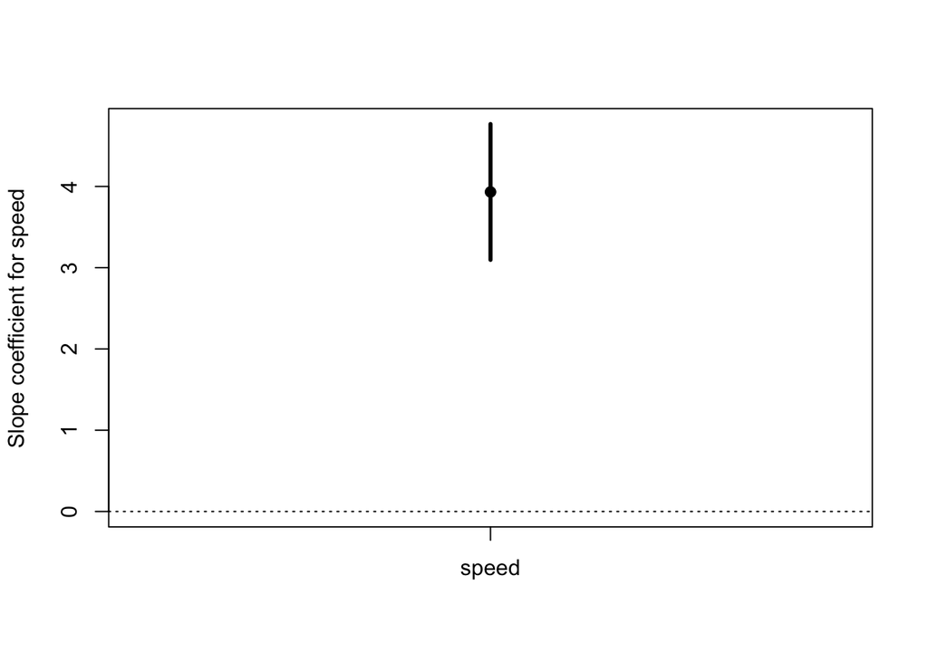

```r
fit <- lm(dist ~ speed, data = cars)

slope <- coef(fit)["speed"]
slope_ci <- confint(fit)["speed", ]

plot(
  1, slope,
  xlim = c(0.5, 1.5),
  ylim = range(c(0, slope_ci)),
  xaxt = "n",
  xlab = "",
  ylab = "Slope coefficient for speed",
  pch = 19
)

segments(
  x0 = 1,
  y0 = slope_ci[1],
  x1 = 1,
  y1 = slope_ci[2],
  lwd = 3
)

points(1, slope, pch = 19)
axis(1, at = 1, labels = "speed")
abline(h = 0, lty = 3)
```

## Plot confidence and prediction bands

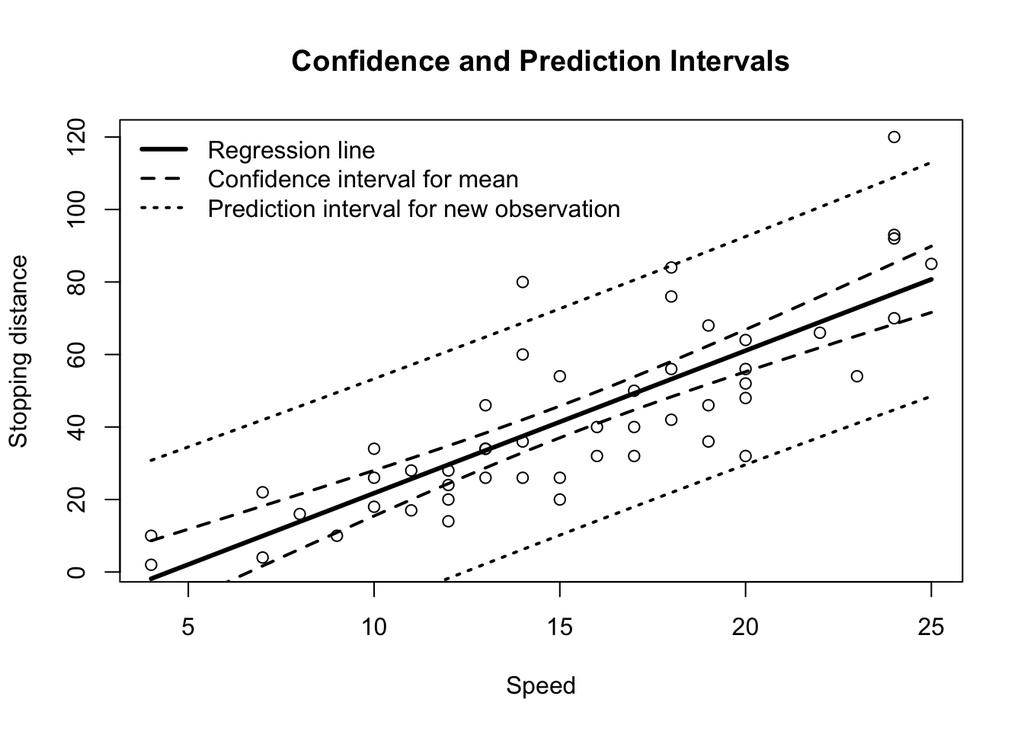

```r
fit <- lm(dist ~ speed, data = cars)

speed_grid <- data.frame(
  speed = seq(
    from = min(cars$speed),
    to = max(cars$speed),
    length.out = 200
  )
)

conf_band <- predict(
  fit,
  newdata = speed_grid,
  interval = "confidence",
  level = 0.95
)

pred_band <- predict(
  fit,
  newdata = speed_grid,
  interval = "prediction",
  level = 0.95
)

plot(
  cars$speed,
  cars$dist,
  xlab = "Speed",
  ylab = "Stopping distance",
  main = "Confidence and Prediction Intervals"
)

lines(speed_grid$speed, conf_band[, "fit"], lwd = 3)
lines(speed_grid$speed, conf_band[, "lwr"], lty = 2, lwd = 2)
lines(speed_grid$speed, conf_band[, "upr"], lty = 2, lwd = 2)
lines(speed_grid$speed, pred_band[, "lwr"], lty = 3, lwd = 2)
lines(speed_grid$speed, pred_band[, "upr"], lty = 3, lwd = 2)

legend(
  "topleft",
  legend = c(
    "Regression line",
    "Confidence interval for mean",
    "Prediction interval for new observation"
  ),
  lty = c(1, 2, 3),
  lwd = c(3, 2, 2),
  bty = "n"
)
```

## The same point prediction sits at the center of both intervals

```r
fit <- lm(dist ~ speed, data = cars)

b <- coef(fit)

# Calculate the prediction literally from the coefficients
manual_prediction <- b[1] + b[2] * 15
manual_prediction
```

```
## (Intercept)
##    41.40704
```

```r
# Ask predict() for the point prediction
predict(
  fit,
  newdata = data.frame(speed = 15)
)
```

```
##        1
## 41.40704
```

## Multiple regression and holding predictors fixed

```r
fit_simple <- lm(mpg ~ am, data = mtcars)
fit_multiple <- lm(mpg ~ wt + am, data = mtcars)

coef(fit_simple)
```

```
## (Intercept)          am
##   17.147368    7.244939
```

```r
coef(fit_multiple)
```

```
## (Intercept)          wt          am
## 37.32155131 -5.35281145 -0.02361522
```

```r
# Two cars with exactly the same weight
same_weight <- data.frame(
  wt = c(3, 3),
  am = c(0, 1)
)

predicted_mpg <- predict(
  fit_multiple,
  newdata = same_weight
)

predicted_mpg
```

```
##        1        2
## 21.26312 21.23950
```

```r
predicted_mpg[2] - predicted_mpg[1]
```

```
##           2
## -0.02361522
```

```r
coef(fit_multiple)["am"]
```

```
##          am
## -0.02361522
```

```r
# Two cars with the same transmission, different weight
same_transmission <- data.frame(
  wt = c(3, 4),
  am = c(0, 0)
)

predicted_mpg <- predict(
  fit_multiple,
  newdata = same_transmission
)

predicted_mpg[2] - predicted_mpg[1]
```

```
##         2
## -5.352811
```

```r
coef(fit_multiple)["wt"]
```

```
##        wt
## -5.352811
```

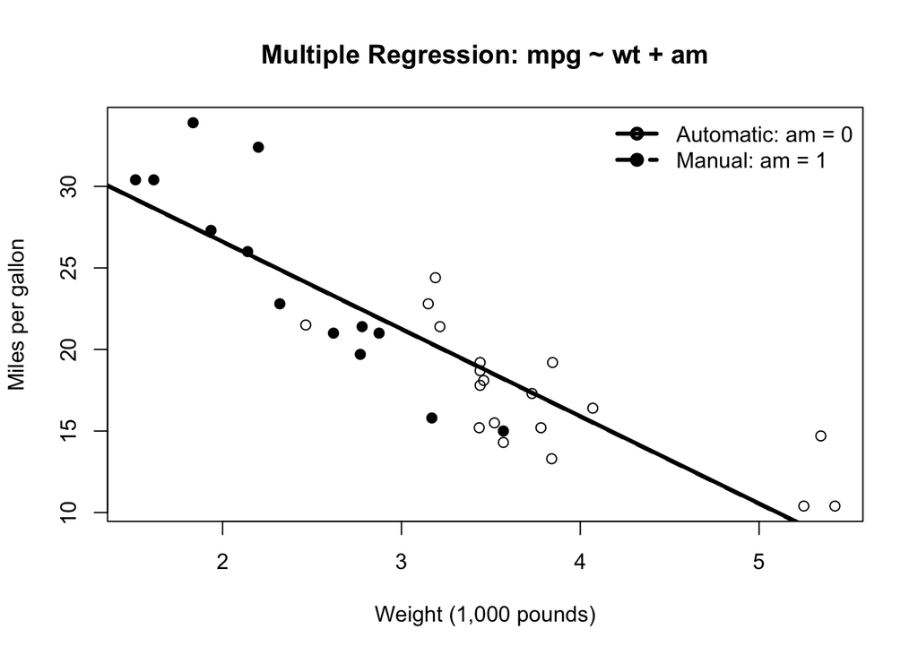

```r
point_type <- ifelse(mtcars$am == 1, 19, 1)

plot(
  mtcars$wt,
  mtcars$mpg,
  pch = point_type,
  xlab = "Weight (1,000 pounds)",
  ylab = "Miles per gallon",
  main = "Multiple Regression: mpg ~ wt + am"
)

b <- coef(fit_multiple)
abline(a = b["(Intercept)"], b = b["wt"], lwd = 3)
abline(
  a = b["(Intercept)"] + b["am"],
  b = b["wt"],
  lwd = 3,
  lty = 2
)

legend(
  "topright",
  legend = c("Automatic: am = 0", "Manual: am = 1"),
  pch = c(1, 19),
  lty = c(1, 2),
  lwd = c(3, 3),
  bty = "n"
)
```

## Partial association: what “holding fixed” means inside OLS

The coefficient on `am` in `mpg ~ wt + am` is the slope of `mpg` on the part of `am` that weight cannot linearly predict (the Frisch–Waugh–Lovell theorem). Here that partial association has the opposite sign from the simple one.

```r
fit_simple <- lm(mpg ~ am, data = mtcars)
fit_multiple <- lm(mpg ~ wt + am, data = mtcars)

# Step 1: the part of am that weight cannot linearly predict
am_resid <- resid(lm(am ~ wt, data = mtcars))

# Step 2: regress mpg on that leftover part
fit_partial <- lm(mpg ~ am_resid, data = mtcars)

coef(fit_simple)["am"]              # about 7.24
```

```
##       am
## 7.244939
```

```r
coef(fit_multiple)["am"]            # about -0.024
```

```
##          am
## -0.02361522
```

```r
coef(fit_partial)["am_resid"]       # identical to the line above
```

```
##    am_resid
## -0.02361522
```

```r
# Transmission and weight are strongly related, so the leftover part
# of am is quite a different variable from am itself:
cor(mtcars$am, mtcars$wt)
```

```
## [1] -0.6924953
```

```r
summary(lm(am ~ wt, data = mtcars))$r.squared
```

```
## [1] 0.4795497
```

## The sign flip, continued: decomposition, support, and specification

The omitted-variable identity `beta_short = beta_long + gamma * delta` accounts for the entire change from 7.24 to -0.024. The comparison “at equal weight” rests on only 17 of the 32 cars, and the coefficient on `am` depends on which controls are included.

```r
fit_short <- lm(mpg ~ am, data = mtcars)
fit_long <- lm(mpg ~ wt + am, data = mtcars)

gamma <- coef(fit_long)["wt"]                     # weight, long regression
delta <- coef(lm(wt ~ am, data = mtcars))["am"]   # slope of weight on am

coef(fit_long)["am"] + gamma * delta   # reproduces the short coefficient
```

```
##       am
## 7.244939
```

```r
coef(fit_short)["am"]
```

```
##       am
## 7.244939
```

```r
tapply(mtcars$wt, mtcars$am, range)
```

```
## $`0`
## [1] 2.465 5.424
##
## $`1`
## [1] 1.513 3.570
```

```r
# Cars inside the weight range where both groups are observed
with(mtcars, table(am, in_overlap = wt >= 2.465 & wt <= 3.570))
```

```
##    in_overlap
## am  FALSE TRUE
##   0     8   11
##   1     7    6
```

```r
c(
  am_only        = coef(lm(mpg ~ am, data = mtcars))["am"],
  plus_wt        = coef(lm(mpg ~ am + wt, data = mtcars))["am"],
  plus_wt_hp     = coef(lm(mpg ~ am + wt + hp, data = mtcars))["am"],
  plus_wt_qsec   = coef(lm(mpg ~ am + wt + qsec, data = mtcars))["am"],
  plus_wt_hp_cyl = coef(lm(mpg ~ am + wt + hp + factor(cyl),
                           data = mtcars))["am"]
)
```

```
##        am_only.am        plus_wt.am     plus_wt_hp.am   plus_wt_qsec.am
##        7.24493927       -0.02361522        2.08371013        2.93583719
## plus_wt_hp_cyl.am
##        1.80921138
```

## Interactions and centering

```r
fit_interaction <- lm(mpg ~ wt * am, data = mtcars)
summary(fit_interaction)
```

```
##
## Call:
## lm(formula = mpg ~ wt * am, data = mtcars)
##
## Residuals:
##     Min      1Q  Median      3Q     Max
## -3.6004 -1.5446 -0.5325  0.9012  6.0909
##
## Coefficients:
##             Estimate Std. Error t value Pr(>|t|)
## (Intercept)  31.4161     3.0201  10.402 4.00e-11 ***
## wt           -3.7859     0.7856  -4.819 4.55e-05 ***
## am           14.8784     4.2640   3.489  0.00162 **
## wt:am        -5.2984     1.4447  -3.667  0.00102 **
## ---
## Signif. codes:  0 '***' 0.001 '**' 0.01 '*' 0.05 '.' 0.1 ' ' 1
##
## Residual standard error: 2.591 on 28 degrees of freedom
## Multiple R-squared:  0.833,  Adjusted R-squared:  0.8151
## F-statistic: 46.57 on 3 and 28 DF,  p-value: 5.209e-11
```

```r
mtcars_for_example <- mtcars
mtcars_for_example$wt_centered <-
  mtcars_for_example$wt - mean(mtcars_for_example$wt)

fit_interaction_centered <- lm(
  mpg ~ wt_centered * am,
  data = mtcars_for_example
)
summary(fit_interaction_centered)
```

```
##
## Call:
## lm(formula = mpg ~ wt_centered * am, data = mtcars_for_example)
##
## Residuals:
##     Min      1Q  Median      3Q     Max
## -3.6004 -1.5446 -0.5325  0.9012  6.0909
##
## Coefficients:
##                Estimate Std. Error t value Pr(>|t|)
## (Intercept)     19.2358     0.7357  26.147  < 2e-16 ***
## wt_centered     -3.7859     0.7856  -4.819 4.55e-05 ***
## am              -2.1677     1.4189  -1.528  0.13779
## wt_centered:am  -5.2984     1.4447  -3.667  0.00102 **
## ---
## Signif. codes:  0 '***' 0.001 '**' 0.01 '*' 0.05 '.' 0.1 ' ' 1
##
## Residual standard error: 2.591 on 28 degrees of freedom
## Multiple R-squared:  0.833,  Adjusted R-squared:  0.8151
## F-statistic: 46.57 on 3 and 28 DF,  p-value: 5.209e-11
```

With the interaction, the fitted manual-minus-automatic difference depends on weight; the additive model’s -0.024 hides that.

```r
b <- coef(fit_interaction)

# Fitted manual-minus-automatic difference at a given weight
gap_at <- function(w) b["am"] + b["wt:am"] * w
gap_at(c(2.5, 3.0, 3.5))
```

```
## [1]  1.632521 -1.016659 -3.665839
```

```r
# The weight at which the two fitted lines cross
-b["am"] / b["wt:am"]
```

```
##       am
## 2.808118
```

## A confidence interval when a confounder is omitted

The short regression omits the confounder `z`. Its confidence interval is still a valid 95% interval – for the projection coefficient `beta1`, not for the causal effect `alpha1`. Watch what happens to each coverage rate as `n` grows.

```r
set.seed(11)

alpha1 <- 2.00   # the causal effect of x on y
alpha2 <- 0.15   # the effect of the omitted confounder z on y

one_study <- function(n) {
  z <- rnorm(n)
  x <- 0.7 * z + rnorm(n)                      # x and z are related
  y <- 1 + alpha1 * x + alpha2 * z + rnorm(n)
  fit <- lm(y ~ x)                             # z omitted
  ci <- confint(fit)["x", ]
  c(est = unname(coef(fit)["x"]),
    lower = unname(ci[1]),
    upper = unname(ci[2]))
}

# What the short regression actually targets: beta1 = alpha1 + alpha2 * delta1,
# where delta1 is the population slope of z on x.
delta1 <- 0.7 / (0.7^2 + 1)
beta1 <- alpha1 + alpha2 * delta1
beta1
```

```
## [1] 2.07047
```

```r
coverage <- function(n, reps = 2000) {
  out <- replicate(reps, one_study(n))
  c(n                 = n,
    mean_estimate     = mean(out["est", ]),
    covers_causal     = mean(out["lower", ] <= alpha1 & out["upper", ] >= alpha1),
    covers_projection = mean(out["lower", ] <= beta1  & out["upper", ] >= beta1))
}

round(rbind(coverage(100), coverage(1000), coverage(10000)), 4)
```

```
##          n mean_estimate covers_causal covers_projection
## [1,]   100        2.0695         0.863            0.9475
## [2,]  1000        2.0709         0.229            0.9545
## [3,] 10000        2.0708         0.000            0.9495
```

Coverage of `beta1` sits at the advertised 95% at every sample size. Coverage of `alpha1` falls toward zero, because the interval narrows while the bias does not. The estimates are not getting worse – they are converging, precisely, on the wrong quantity.

# Chapter 4: Functional Form, Interactions, Interpolation, and Extrapolation

## Functional form

```r
set.seed(9)

x <- seq(1, 10, length.out = 100)
y <- 5 + 2 * x - 0.25 * x^2 + rnorm(100, sd = 1.5)
dat_functional <- data.frame(x, y)

fit_linear <- lm(y ~ x, data = dat_functional)
fit_quadratic <- lm(y ~ x + I(x^2), data = dat_functional)
fit_cubic <- lm(y ~ x + I(x^2) + I(x^3), data = dat_functional)
fit_logx <- lm(y ~ log(x), data = dat_functional)

summary(fit_linear)$r.squared
```

```
## [1] 0.4643643
```

```r
summary(fit_quadratic)$r.squared
```

```
## [1] 0.767135
```

```r
summary(fit_cubic)$r.squared
```

```
## [1] 0.7671361
```

```r
summary(fit_logx)$r.squared
```

```
## [1] 0.2625474
```

## An additive model imposes parallel lines

```r
fit_additive_hp <- lm(mpg ~ hp + am, data = mtcars)
summary(fit_additive_hp)
```

```
##
## Call:
## lm(formula = mpg ~ hp + am, data = mtcars)
##
## Residuals:
##     Min      1Q  Median      3Q     Max
## -4.3843 -2.2642  0.1366  1.6968  5.8657
##
## Coefficients:
##              Estimate Std. Error t value Pr(>|t|)
## (Intercept) 26.584914   1.425094  18.655  < 2e-16 ***
## hp          -0.058888   0.007857  -7.495 2.92e-08 ***
## am           5.277085   1.079541   4.888 3.46e-05 ***
## ---
## Signif. codes:  0 '***' 0.001 '**' 0.01 '*' 0.05 '.' 0.1 ' ' 1
##
## Residual standard error: 2.909 on 29 degrees of freedom
## Multiple R-squared:  0.782,  Adjusted R-squared:  0.767
## F-statistic: 52.02 on 2 and 29 DF,  p-value: 2.55e-10
```

```r
# One slope on hp serves both groups, so the fitted lines can differ
# only by a constant vertical shift -- the coefficient on am.
coef(fit_additive_hp)
```

```
## (Intercept)          hp          am
##  26.5849137  -0.0588878   5.2770853
```

```r
# Here the restriction costs almost nothing: allowing the slopes to
# differ returns an interaction estimate of essentially zero.
coef(lm(mpg ~ hp * am, data = mtcars))["hp:am"]
```

```
##        hp:am
## 0.0004028907
```

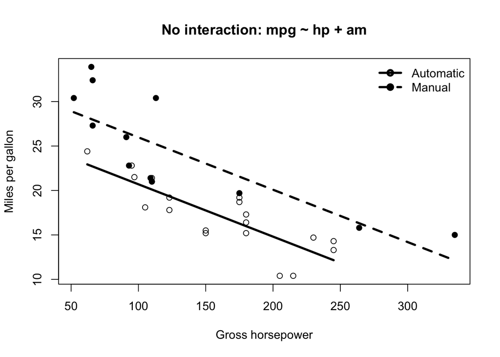

```r
plot(
  mtcars$hp,
  mtcars$mpg,
  pch = ifelse(mtcars$am == 0, 1, 19),
  xlab = "Gross horsepower",
  ylab = "Miles per gallon",
  main = "No interaction: mpg ~ hp + am"
)

auto_hp <- seq(
  min(mtcars$hp[mtcars$am == 0]),
  max(mtcars$hp[mtcars$am == 0]),
  length.out = 100
)

manual_hp <- seq(
  min(mtcars$hp[mtcars$am == 1]),
  max(mtcars$hp[mtcars$am == 1]),
  length.out = 100
)

auto_pred <- predict(
  fit_additive_hp,
  newdata = data.frame(hp = auto_hp, am = 0)
)

manual_pred <- predict(
  fit_additive_hp,
  newdata = data.frame(hp = manual_hp, am = 1)
)

lines(auto_hp, auto_pred, lwd = 3)
lines(manual_hp, manual_pred, lwd = 3, lty = 2)

legend(
  "topright",
  legend = c("Automatic", "Manual"),
  pch = c(1, 19),
  lty = c(1, 2),
  lwd = c(3, 3),
  bty = "n"
)
```

## Additive model versus interaction model

```r
fit_additive <- lm(mpg ~ wt + am, data = mtcars)
fit_interaction <- lm(mpg ~ wt * am, data = mtcars)

summary(fit_additive)
```

```
##
## Call:
## lm(formula = mpg ~ wt + am, data = mtcars)
##
## Residuals:
##     Min      1Q  Median      3Q     Max
## -4.5295 -2.3619 -0.1317  1.4025  6.8782
##
## Coefficients:
##             Estimate Std. Error t value Pr(>|t|)
## (Intercept) 37.32155    3.05464  12.218 5.84e-13 ***
## wt          -5.35281    0.78824  -6.791 1.87e-07 ***
## am          -0.02362    1.54565  -0.015    0.988
## ---
## Signif. codes:  0 '***' 0.001 '**' 0.01 '*' 0.05 '.' 0.1 ' ' 1
##
## Residual standard error: 3.098 on 29 degrees of freedom
## Multiple R-squared:  0.7528, Adjusted R-squared:  0.7358
## F-statistic: 44.17 on 2 and 29 DF,  p-value: 1.579e-09
```

```r
summary(fit_interaction)
```

```
##
## Call:
## lm(formula = mpg ~ wt * am, data = mtcars)
##
## Residuals:
##     Min      1Q  Median      3Q     Max
## -3.6004 -1.5446 -0.5325  0.9012  6.0909
##
## Coefficients:
##             Estimate Std. Error t value Pr(>|t|)
## (Intercept)  31.4161     3.0201  10.402 4.00e-11 ***
## wt           -3.7859     0.7856  -4.819 4.55e-05 ***
## am           14.8784     4.2640   3.489  0.00162 **
## wt:am        -5.2984     1.4447  -3.667  0.00102 **
## ---
## Signif. codes:  0 '***' 0.001 '**' 0.01 '*' 0.05 '.' 0.1 ' ' 1
##
## Residual standard error: 2.591 on 28 degrees of freedom
## Multiple R-squared:  0.833,  Adjusted R-squared:  0.8151
## F-statistic: 46.57 on 3 and 28 DF,  p-value: 5.209e-11
```

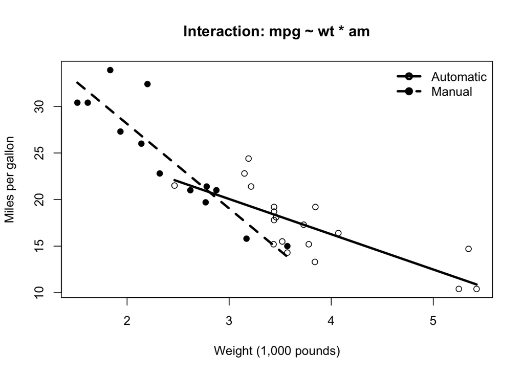

```r
plot(
  mtcars$wt,
  mtcars$mpg,
  pch = ifelse(mtcars$am == 0, 1, 19),
  xlab = "Weight (1,000 pounds)",
  ylab = "Miles per gallon",
  main = "Interaction: mpg ~ wt * am"
)

auto_wt <- seq(
  min(mtcars$wt[mtcars$am == 0]),
  max(mtcars$wt[mtcars$am == 0]),
  length.out = 100
)

manual_wt <- seq(
  min(mtcars$wt[mtcars$am == 1]),
  max(mtcars$wt[mtcars$am == 1]),
  length.out = 100
)

auto_pred <- predict(
  fit_interaction,
  newdata = data.frame(wt = auto_wt, am = 0)
)

manual_pred <- predict(
  fit_interaction,
  newdata = data.frame(wt = manual_wt, am = 1)
)

lines(auto_wt, auto_pred, lwd = 3)
lines(manual_wt, manual_pred, lwd = 3, lty = 2)

legend(
  "topright",
  legend = c("Automatic", "Manual"),
  pch = c(1, 19),
  lty = c(1, 2),
  lwd = c(3, 3),
  bty = "n"
)
```

## Interpolation across an unsupported interior gap

```r
set.seed(26)

x_left <- runif(35, min = 1, max = 4)
x_right <- runif(35, min = 7, max = 10)
x <- c(x_left, x_right)

y <- c(
  2 + 3 * x_left + rnorm(35, mean = 0, sd = 0.5),
  28 - x_right + rnorm(35, mean = 0, sd = 0.5)
)

gap_data <- data.frame(x = x, y = y)

fit_linear <- lm(y ~ x, data = gap_data)
fit_quadratic <- lm(y ~ x + I(x^2), data = gap_data)

new_point <- data.frame(x = 5.5)
predict(fit_linear, newdata = new_point)
```

```
##        1
## 14.47983
```

```r
predict(fit_quadratic, newdata = new_point)
```

```
##        1
## 17.90964
```

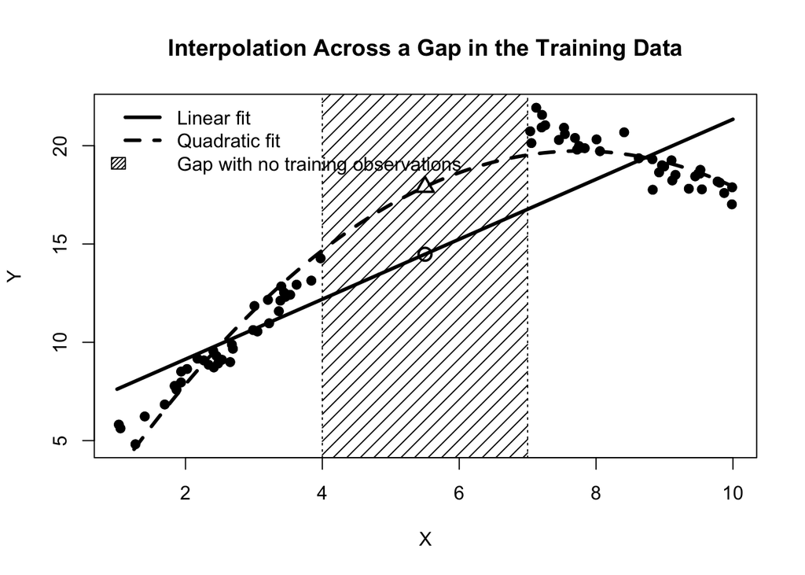

```r
x_grid <- seq(1, 10, length.out = 300)
new_grid <- data.frame(x = x_grid)

linear_hat <- predict(fit_linear, newdata = new_grid)
quadratic_hat <- predict(fit_quadratic, newdata = new_grid)

plot(
  gap_data$x,
  gap_data$y,
  xlab = "X",
  ylab = "Y",
  main = "Interpolation Across a Gap in the Training Data",
  pch = 19
)

rect(
  xleft = 4,
  ybottom = par("usr")[3],
  xright = 7,
  ytop = par("usr")[4],
  density = 12,
  angle = 45,
  border = NA
)

points(gap_data$x, gap_data$y, pch = 19)
lines(x_grid, linear_hat, lwd = 3)
lines(x_grid, quadratic_hat, lwd = 3, lty = 2)
abline(v = c(4, 7), lty = 3)

points(
  5.5,
  predict(fit_linear, newdata = data.frame(x = 5.5)),
  pch = 1,
  cex = 1.5,
  lwd = 2
)

points(
  5.5,
  predict(fit_quadratic, newdata = data.frame(x = 5.5)),
  pch = 2,
  cex = 1.5,
  lwd = 2
)

legend(
  "topleft",
  legend = c(
    "Linear fit",
    "Quadratic fit",
    "Gap with no training observations"
  ),
  lty = c(1, 2, NA),
  lwd = c(3, 3, NA),
  fill = c(NA, NA, "black"),
  density = c(0, 0, 35),
  angle = 45,
  border = c(NA, NA, "black"),
  bty = "n"
)
```

## Extrapolation and functional-form dependence with `faithful`

```r
fit_linear <- lm(waiting ~ eruptions, data = faithful)
fit_quadratic <- lm(
  waiting ~ eruptions + I(eruptions^2),
  data = faithful
)
fit_cubic <- lm(
  waiting ~ eruptions + I(eruptions^2) + I(eruptions^3),
  data = faithful
)

summary(fit_linear)$r.squared
```

```
## [1] 0.8114608
```

```r
summary(fit_quadratic)$r.squared
```

```
## [1] 0.8207779
```

```r
summary(fit_cubic)$r.squared
```

```
## [1] 0.8271686
```

```r
new_case <- data.frame(eruptions = 7)
predict(fit_linear, newdata = new_case)
```

```
##        1
## 108.5819
```

```r
predict(fit_quadratic, newdata = new_case)
```

```
##        1
## 86.14819
```

```r
predict(fit_cubic, newdata = new_case)
```

```
##        1
## 19.81627
```

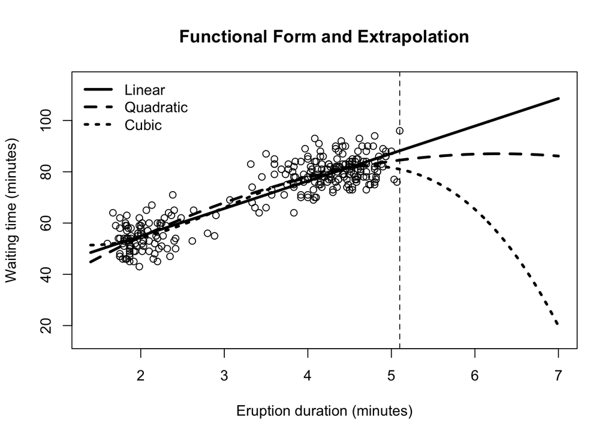

```r
x_grid <- seq(1.4, 7, length.out = 300)
new_grid <- data.frame(eruptions = x_grid)

plot(
  faithful$eruptions,
  faithful$waiting,
  xlim = c(1.4, 7),
  ylim = c(15, 115),
  xlab = "Eruption duration (minutes)",
  ylab = "Waiting time (minutes)",
  main = "Functional Form and Extrapolation"
)

lines(x_grid, predict(fit_linear, newdata = new_grid), lwd = 3)
lines(
  x_grid,
  predict(fit_quadratic, newdata = new_grid),
  lwd = 3,
  lty = 2
)
lines(
  x_grid,
  predict(fit_cubic, newdata = new_grid),
  lwd = 3,
  lty = 3
)

abline(v = max(faithful$eruptions), lty = 2)

legend(
  "topleft",
  legend = c("Linear", "Quadratic", "Cubic"),
  lty = c(1, 2, 3),
  lwd = c(3, 3, 3),
  bty = "n"
)
```

## LOESS and extrapolation

```r
fit_loess <- loess(waiting ~ eruptions, data = faithful)

predict(
  fit_loess,
  newdata = data.frame(eruptions = c(2, 4, 7))
)
```

```
##        1        2        3
## 54.16439 78.81044       NA
```

## Support in multiple regression: an unequally supported comparison

Automatic cars in `mtcars` weigh roughly 2.47 to 5.42 thousand pounds; manual cars roughly 1.51 to 3.57. At a weight of 5, the automatic prediction is supported by nearby observations, but the manual prediction is an extrapolation.

```r
fit_interaction <- lm(mpg ~ wt * am, data = mtcars)

predict(
  fit_interaction,
  newdata = data.frame(
    wt = c(5, 5),
    am = c(0, 1)
  )
)
```

```
##          1          2
## 12.4865177  0.8731378
```

```r
range(mtcars$wt[mtcars$am == 0])
```

```
## [1] 2.465 5.424
```

```r
range(mtcars$wt[mtcars$am == 1])
```

```
## [1] 1.513 3.570
```

# Chapter 5: Regression, Overlap, Model Dependence, and Causal Inference

## A constructed observational study with limited overlap

The treatment effect in this constructed dataset is exactly 6. Treatment status is strongly related to `x`, and the untreated outcome function is nonlinear.

```r
x_control <- rep(0:8, each = 3)
x_treated <- rep(5:16, each = 3)

noise_control <- rep(c(-1, 0, 1), times = 9)
noise_treated <- rep(c(-1, 0, 1), times = 12)

Y0_control <- 5 + x_control + 0.4 * x_control^2 + noise_control
Y0_treated <- 5 + x_treated + 0.4 * x_treated^2 + noise_treated

D <- c(
  rep(0, length(x_control)),
  rep(1, length(x_treated))
)

x <- c(x_control, x_treated)
Y <- c(Y0_control, Y0_treated + 6)

causal_dat <- data.frame(Y, D, x)
```

## Model dependence under poor overlap

```r
fit_linear_adjustment <- lm(
  Y ~ D + x,
  data = causal_dat
)

fit_quadratic_adjustment <- lm(
  Y ~ D + x + I(x^2),
  data = causal_dat
)

coef(fit_linear_adjustment)["D"]
```

```
##        D
## 1.190148
```

```r
coef(fit_quadratic_adjustment)["D"]
```

```
## D
## 6
```

The two specifications use the same observations but impose different functional forms. The correctly specified quadratic model recovers 6, while the linear adjustment gives a very different answer because the groups have limited overlap.

## Seeing model dependence

Each adjustment draws parallel fitted outcome functions for controls (solid) and treated units (dashed); the vertical gap is the estimated effect. Outside the shaded overlap band, each function is an extrapolation for one group. At `x = 12` no control unit is observed, so the untreated counterfactual there comes entirely from the assumed shape.

```r
# Predicted untreated outcome for treated units at x = 12
predict(fit_linear_adjustment, newdata = data.frame(D = 0, x = 12))
```

```
##       1
## 80.9711
```

```r
predict(fit_quadratic_adjustment, newdata = data.frame(D = 0, x = 12))
```

```
##    1
## 74.6
```

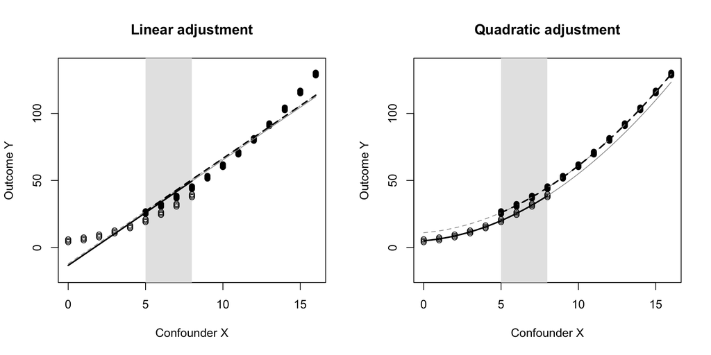

```r
# Draw a group's fitted function in black over [from, to],
# its observed support, and in grey elsewhere (extrapolation)
draw_fit <- function(fit, d, from, to, lty) {
  full <- seq(0, 16, length.out = 200)
  supported <- seq(from, to, length.out = 100)
  lines(
    full,
    predict(fit, newdata = data.frame(D = d, x = full)),
    col = "grey60",
    lty = lty
  )
  lines(
    supported,
    predict(fit, newdata = data.frame(D = d, x = supported)),
    lwd = 2,
    lty = lty
  )
}

plot_adjustment <- function(fit, title) {
  plot(
    causal_dat$x,
    causal_dat$Y,
    type = "n",
    ylim = c(-20, 135),
    xlab = "Confounder X",
    ylab = "Outcome Y",
    main = title
  )
  rect(5, -30, 8, 145, col = "grey90", border = NA)
  points(
    causal_dat$x,
    causal_dat$Y,
    pch = ifelse(causal_dat$D == 1, 19, 1)
  )
  draw_fit(fit, d = 0, from = 0, to = 8, lty = 1)    # controls
  draw_fit(fit, d = 1, from = 5, to = 16, lty = 2)   # treated
}

par(mfrow = c(1, 2))
plot_adjustment(fit_linear_adjustment, "Linear adjustment")
plot_adjustment(fit_quadratic_adjustment, "Quadratic adjustment")
```

```r
par(mfrow = c(1, 1))
```

## Restrict to the region of common support

```r
overlap_dat <- causal_dat[
  causal_dat$x >= 5 & causal_dat$x <= 8,
]

fit_linear_overlap <- lm(
  Y ~ D + x,
  data = overlap_dat
)

fit_quadratic_overlap <- lm(
  Y ~ D + x + I(x^2),
  data = overlap_dat
)

coef(fit_linear_overlap)["D"]
```

```
## D
## 6
```

```r
coef(fit_quadratic_overlap)["D"]
```

```
## D
## 6
```

In this deliberately clean example, both specifications now return 6 because treated and control outcomes are directly compared at the same `x` values.

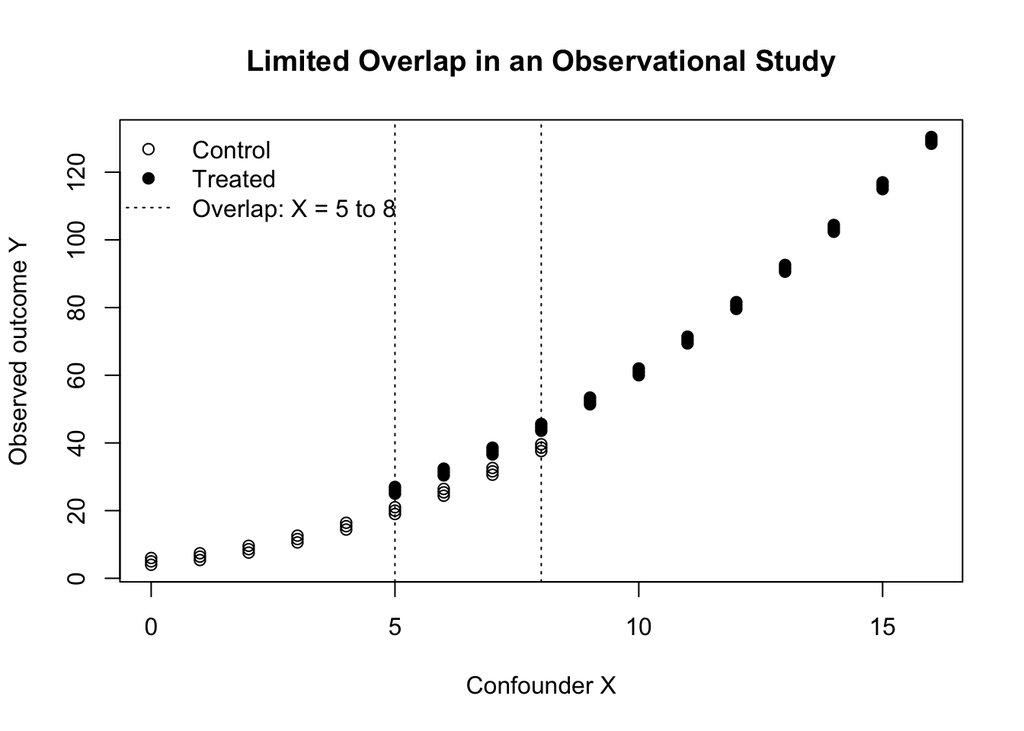

```r
plot(
  causal_dat$x,
  causal_dat$Y,
  pch = ifelse(causal_dat$D == 1, 19, 1),
  xlab = "Confounder X",
  ylab = "Observed outcome Y",
  main = "Limited Overlap in an Observational Study"
)

abline(v = 5, lty = 3)
abline(v = 8, lty = 3)

legend(
  "topleft",
  legend = c("Control", "Treated", "Overlap: X = 5 to 8"),
  pch = c(1, 19, NA),
  lty = c(NA, NA, 3),
  bty = "n"
)
```

## A perfectly balanced randomized-design illustration

This final example represents a perfectly balanced assignment within each value of `x`: three of six units receive treatment and three receive control. The true treatment effect remains 6. Because treatment and control have the same covariate support and distribution here, the treatment-only regression and two differently specified adjusted regressions all recover the same treatment contrast in this constructed dataset.

```r
x <- rep(0:16, each = 6)
D <- rep(c(0, 0, 0, 1, 1, 1), times = 17)
noise <- rep(c(-1, 0, 1, -1, 0, 1), times = 17)

Y0 <- 5 + x + 0.4 * x^2 + noise
Y <- Y0 + 6 * D

rct_dat <- data.frame(Y, D, x)

# Difference in means = treatment-only OLS coefficient
mean(rct_dat$Y[rct_dat$D == 1]) -
  mean(rct_dat$Y[rct_dat$D == 0])
```

```
## [1] 6
```

```r
fit_rct_simple <- lm(Y ~ D, data = rct_dat)
fit_rct_linear <- lm(Y ~ D + x, data = rct_dat)
fit_rct_quadratic <- lm(Y ~ D + x + I(x^2), data = rct_dat)

coef(fit_rct_simple)["D"]
```

```
## D
## 6
```

```r
coef(fit_rct_linear)["D"]
```

```
## D
## 6
```

```r
coef(fit_rct_quadratic)["D"]
```

```
## D
## 6
```

The linear adjustment is as misspecified here as in the observational study, yet it returns exactly 6. Both groups occupy the same values of `x`, so they share the same misfit and it cancels from the comparison.

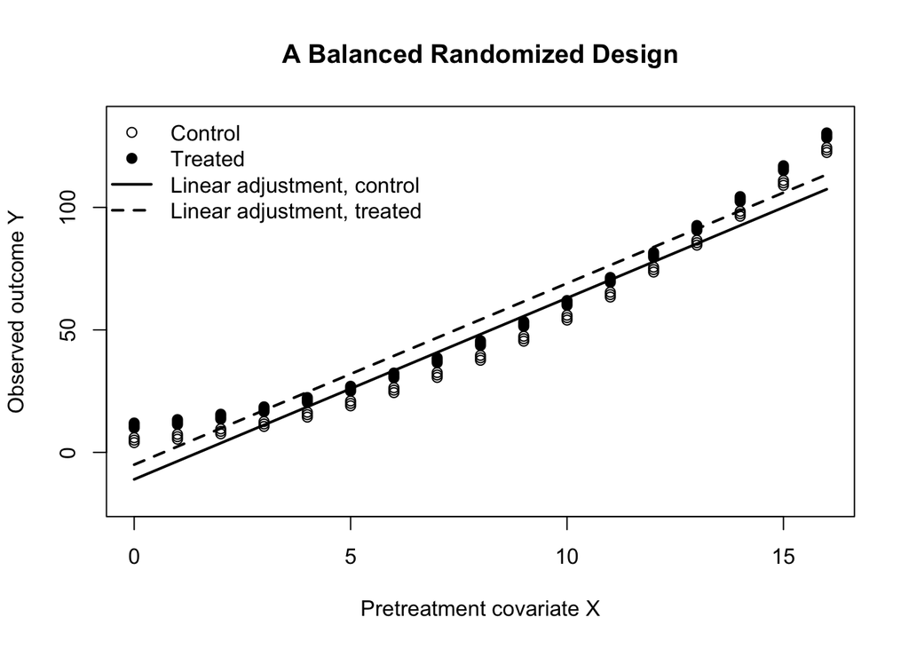

```r
x_grid <- seq(0, 16, length.out = 200)

plot(
  rct_dat$x,
  rct_dat$Y,
  pch = ifelse(rct_dat$D == 1, 19, 1),
  ylim = c(-20, 135),
  xlab = "Pretreatment covariate X",
  ylab = "Observed outcome Y",
  main = "A Balanced Randomized Design"
)

lines(
  x_grid,
  predict(fit_rct_linear, newdata = data.frame(D = 0, x = x_grid)),
  lwd = 2
)
lines(
  x_grid,
  predict(fit_rct_linear, newdata = data.frame(D = 1, x = x_grid)),
  lwd = 2,
  lty = 2
)

legend(
  "topleft",
  legend = c(
    "Control",
    "Treated",
    "Linear adjustment, control",
    "Linear adjustment, treated"
  ),
  pch = c(1, 19, NA, NA),
  lty = c(NA, NA, 1, 2),
  lwd = c(NA, NA, 2, 2),
  bty = "n"
)
```

# Suggested experiments for students

These are useful modifications to try after working through the notebook:

1. Change the values passed to `predict()` in the `cars` examples and watch how point predictions change.
2. Compare confidence and prediction interval widths near the middle and edges of the observed `speed` range.
3. Add an irrelevant predictor to an OLS model and verify that training-set R-squared cannot fall.
4. In the interpolation-gap example, move the gap or make it wider and compare the linear and quadratic predictions.
5. In the causal-overlap example, gradually shrink the overlap region and watch the treatment coefficient become more sensitive to functional form.
6. In the `mtcars` interaction model, predict manual and automatic mileage at the same weights and inspect where those comparisons are supported by actual data.